# Deconvolution of PCLS bulk RNASeq using IPF Atlas scRNAseq using Bisque

### Part2 b. Sample Size reduction of the single cell RNAseq dataset:

```r
combined_subjects <- readRDS("combined_subjects.rds")
```

[output not shown]

New we must generate a new list of all cell information with the addition of new subject identification. This object is also stored as an RDS object

```r
all_celltypes_new <- merge(all_celltypes, combined_subjects, by.x = "Subject_Identity", by.y = "original_subject_id",all.x = T)

saveRDS(all_celltypes_new, "data/IPF_cell_atlas/all_celltypes_new.rds")
```

Although this has reduced the number of patients. Our computational limitations required us to reduce the sample size more in order to be able to run the data analysis. We therefore decided to use cells from 5 control combined subject groups and 5 IPF combined groups, resulting in a total of 30 real subject data.

```r
#selecting 5 normal subjects and 5 IPF subjects randomly
normalsubjects_new <- unique(all_celltypes_new[all_celltypes_new$Disease_Identity=="Control",]$new_label)
normalsubjects_5random_new <- normalsubjects_new[sample(1:length(normalsubjects_new),5)]

IPFsubjects_new <- unique(all_celltypes_new[all_celltypes_new$Disease_Identity=="IPF",]$new_label)
IPFsubjects_5random_new <- IPFsubjects_new[sample(1:length(IPFsubjects_new),5)]

#combine all selected and store them in csv. NOTE: these will be different if the code is run again since they are sampled randomly, therefore the csv is saved with the date and id of the time they are selected

selected_subjects_new <- c(normalsubjects_5random_new , IPFsubjects_5random_new )


#save list with the date they are produced
write.csv(selected_subjects_new, file =paste0("data/IPF_cell_atlas/selected_subjects_new",gsub(":","-",gsub(" ","-",date())),".csv"))
```

Now can generate an updated all cell meta data, the new list is refered to as all_celltypes.short

```r
all_celltypes_new <- readRDS("data/IPF_cell_atlas/all_celltypes_new.rds")
selected_subjects <- read.csv("data/IPF_cell_atlas/selected_subjects_newFri-Aug-14-21-43-29-2020.csv", header = T, stringsAsFactors = F)$x
all_celltypes.short <- all_celltypes_new[all_celltypes_new$new_label %in% selected_subjects,]
```

Additionally, the dataset has an unrealistic proportion of macrophages in the dataset making up more than 50 percent of the dataset.The proportion of cell types in the reference dataset highly influences the output of bisque reference based decomposition. Thus, we have reduced the number of macrophages on the dataset based on percentages published in a mouse single cell dataset where the proportions of celltypes are more accurate. The selection of macrophages in this analysis was done randomly across samples.

```r
###Code added to randomly select and keep half all macrophages
#count macrophages
macrophage_amount <- round(nrow(all_celltypes.short)*0.035)
macrophages_ids <- all_celltypes.short[all_celltypes.short$Manuscript_Identity=="Macrophage",]$CellBarcode_Identity
macrophages_to_remove <- macrophages_ids[sample(1:length(macrophages_ids),length(macrophages_ids)-macrophage_amount)]
saveRDS(macrophages_to_remove, paste("macrophages_to_remove_",gsub(":","-",gsub(" ","_",date())),".rds"))


#remove.macrophages from list
all_celltypes.short <- all_celltypes.short[!(all_celltypes.short$CellBarcode_Identity %in% macrophages_to_remove),]

#count Alveolar macrophages
alv_macrophage_amount <- round(nrow(all_celltypes.short)*0.016)
alv_macrophages_ids <- all_celltypes.short[all_celltypes.short$Manuscript_Identity=="Macrophage_Alveolar",]$CellBarcode_Identity
alv_macrophages_to_remove <- alv_macrophages_ids[sample(1:length(alv_macrophages_ids),length(alv_macrophages_ids)-alv_macrophage_amount)]

saveRDS(alv_macrophages_to_remove, paste("alv_macrophages_to_remove_",gsub(":","-",gsub(" ","_",date())),".rds"))

#remove.alveolar.macrophages from list
all_celltypes.short <- all_celltypes.short[!(all_celltypes.short$CellBarcode_Identity %in% alv_macrophages_to_remove),]
```

Additionally, we needed to reduce the size of the dataset, we therefore reduced the number cells in each cellytype by 50% by randomly selecting cells from each celltype from each patient. This approach is intended to retain the heterogeneity between subjects and equal effect distribution from each subject.

```r
###Reduce the number of cells for each cell type, from each patient, by fraction
#get lables for all subjects:
subjects <- unique(all_celltypes.short$Subject_Identity)
#loop through each patient.
for (subject in subjects){
    s_cell_types <- unique(all_celltypes.short[all_celltypes.short$Subject_Identity == subject,]$Manuscript_Identity)
  #loop through the celltypes and reduce the number of cells by the given fraction
    for (cell in s_cell_types){
          total_cells <-  all_celltypes.short[all_celltypes.short$Subject_Identity == subject &   all_celltypes.short$Manuscript_Identity == cell,]
          total_cells_count <- nrow(total_cells)
          amount_to_remove <- (0.50 * total_cells_count)
          cells_to_remove <- total_cells[sample(1:total_cells_count,amount_to_remove),]$CellBarcode_Identity
    #remove cells from list
    all_celltypes.short <- all_celltypes.short[!(all_celltypes.short$CellBarcode_Identity %in% cells_to_remove),]
    }
}
```

### Part2 c. Preparetion of single cell Expression set:

The data matrix is stored as a Sparse Matrix. ExpressionSet can only process dense matrix. We perform all filtration steps on the sparse matrix first, then convert it to a dense matrix. Luckily, all filtration steps have been applied to the meta_data, we no only need to select the cells from the single cell count matrix. PS. this part was performed on the computing cluster.

```r
#define variables for new matrix:
#cell barcodes
sample.ids.short <- all_celltypes.short$CellBarcode_Identity
#cell types noted
cell.type.labels.short <- all_celltypes.short$Manuscript_Identity
#subject information: here we use the newly formed subjects.
individual.labels.short <- all_celltypes.short$new_label

# individual.ids and cell.types should be in the same order as in sample.ids
sc.pheno <- data.frame(check.names=F, check.rows=F,
                       stringsAsFactors=F,
                       row.names=sample.ids.short,
                       SubjectName=individual.labels.short,
                       cellType=cell.type.labels.short)

sc.meta <- data.frame(labelDescription=c("SubjectName",
                                         "cellType"),
                      row.names=c("SubjectName",
                                  "cellType"))
sc.pdata <- new("AnnotatedDataFrame",
                data=sc.pheno,
                varMetadata=sc.meta)


#Read Sparse Matrix.
sc.counts.sparse.matrix <- readMM("/home/ha8343al/bisque/data/IPF_cell_atlas/RawCounts_Sparse.mtx")

#define column and rownames
colnames(sc.counts.sparse.matrix) <- sample.ids
rownames(sc.counts.sparse.matrix) <- sc.genes

#Filter sparse matrix according to filtration.
sc.counts.sparse.matrix <- sc.counts.sparse.matrix[,colnames(sc.counts.sparse.matrix) %in% sample.ids.short]

#re_order matrix columns (i.e. barcodes) according to the same order found in the expressionSet Phenotype Data.
sc.counts.sparse.matrix <- sc.counts.sparse.matrix[,sample.ids.short]

#Convert sparse matrix to dense matrix.
sc.counts.matrix <- as.matrix(sc.counts.sparse.matrix)

#To preserve memory, sparse matrix object is removed.
rm(sc.counts.sparse.matrix)

#finally, creat the expressionSet for the single cell data.
sc.eset <- Biobase::ExpressionSet(assayData=sc.counts.matrix,
                                  phenoData=sc.pdata)
```

## Part 3: Preparation of marker list for bisque analysis:

```r
#gene annotation was done with BioMart and stored in csv as G_list.
read.csv("/home/ha8343al/bisque/G_list.csv") -> G_list
```

[output not shown]

## Part4: Run Bisque analysis:

```r
#load bulk PCLS data prepart in Part1
hPCLS <- readRDS("hPCLSNormEsetENSG.rds")
ENSG.markers <- readRDS("ENSGMarkers.rds")

gc()
#run Bisque reference based RNA with Markers supplemented
res <- BisqueRNA::ReferenceBasedDecomposition(bulk.eset = hPCLS
                                              ,sc.eset = sc.eset
                                              ,markers = ENSG.markers$ensembl_gene_id
                                              ,use.overlap = FALSE
                                              ,old.cpm=FALSE)

ref.based.estimates <- res$bulk.props


saveRDS(res, paste("results_",gsub(":","-",gsub(" ","_",date())),".rds"))
saveRDS(all_celltypes.short, paste("Cells_used_",gsub(":","-",gsub(" ","_",date())),".rds"))
```

## Results:

The results of the Bisque analysis will give cell proportions as a fraction of 1 for each sample. The sum of all celltypes for a single sample will equal one. Thus, graphs will be generated as percentage of cells.

```r
results <- readRDS("data/Bisque/results_ Sat_Aug_15_13-13-03_2020_noID.rds")
as.data.frame(results$bulk.props)
```

|  | Patient2_1 | Patient2_2 | Patient2_3 | Patient2_4 | Patient1_1 | Patient1_2 | Patient1_3 | Patient1_4 |
| --- | --- | --- | --- | --- | --- | --- | --- | --- |
| Aberrant_Basaloid | 3.912455e-02 | 0.0348409113 | 0.0205962527 | 1.475249e-02 | 0.000000000 | 0.0000000000 | 0.0000000000 | 0.0000000000 |
| ATI | 9.265369e-03 | 0.0084972169 | 0.0041609189 | 2.840330e-03 | 0.002935424 | 0.0000000000 | 0.0064160809 | 0.0018604147 |
| ATII | 6.416857e-03 | 0.0043022359 | 0.0043083641 | 3.432528e-03 | 0.031495487 | 0.0328455303 | 0.0441508454 | 0.0420876315 |
| B | 3.941948e-02 | 0.0423439229 | 0.0319172128 | 4.264270e-02 | 0.070274183 | 0.0924122380 | 0.0650415688 | 0.0824281786 |
| B_Plasma | 2.614262e-03 | 0.0025818704 | 0.0026214472 | 2.531586e-03 | 0.004001729 | 0.0051665126 | 0.0045161383 | 0.0089224452 |
| Basal | 0.000000e+00 | 0.0024034759 | 0.0000000000 | 0.000000e+00 | 0.028081150 | 0.0000000000 | 0.0261327592 | 0.0008755986 |
| cDC1 | 2.276031e-02 | 0.0226217382 | 0.0162011203 | 1.538719e-02 | 0.000000000 | 0.0000000000 | 0.0000000000 | 0.0000000000 |
| cDC2 | 5.940236e-02 | 0.0456840351 | 0.0327958033 | 2.559961e-02 | 0.000000000 | 0.0515861201 | 0.0000000000 | 0.0506790386 |
| Ciliated | 5.308419e-02 | 0.0544731373 | 0.0679419713 | 7.692645e-02 | 0.030969087 | 0.1493298710 | 0.0373133765 | 0.0795521696 |
| Club | 7.085160e-03 | 0.0085672560 | 0.0100465077 | 1.224705e-02 | 0.003231632 | 0.0269004910 | 0.0048674126 | 0.0157598437 |

[output cut: 29 more lines]

Graphing the cell percentages: One graph contains all. PS. Multiplets will be removed from the graphs as they are not specific for a known cell type.

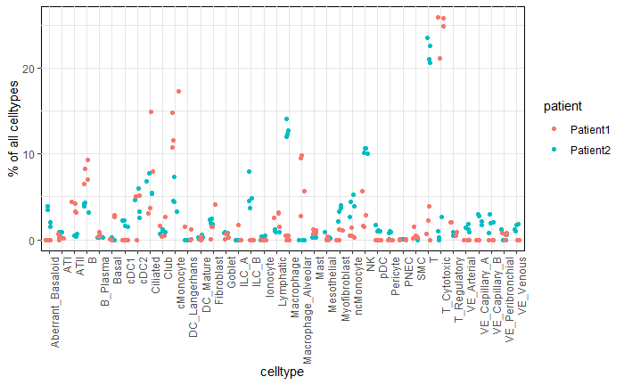

```r
#Obtain reference based estimates (RBE) from results and multiply by 100 to get percentages
RBE <- 100 * results$bulk.props
#convert to dataframe for ggplot2
RBE.df <- data.frame(RBE)

#transpose dataframe for use with ggplot
RBE.df.t <- as.data.frame(t(RBE.df))

#remove multiples
RBE.df.t$Multiplet <- NULL


#Define Subject Names from Bulk dataset
RBE.df.t$subject <- rownames(RBE.df.t)

#Gather all information in one column defined by subject and celltypes
RBE.df.t %>% gather(key="celltype", value = "value", -subject) -> RBE.df.t.g


#add column with Subject number for grouping
substr(RBE.df.t.g$subject, 1, 8) -> RBE.df.t.g$patient

#Plot all data in a single graph.
ggplot(RBE.df.t.g, aes(fill=patient, y=value, x=celltype, colour=patient)) +
  geom_jitter(stat="identity", width = 0.25) +
  ylab("% of all celltypes") +
  theme(axis.text.x = element_text(angle = 90, hjust = 1)) +
  guides(fill=FALSE) +
  theme(panel.background = element_rect(fill = "white", size = 0.5, color = "black")) +
  theme(panel.grid.major = element_line(colour = "gray90")) +
  theme(panel.grid.minor = element_line(colour = "gray90")) + theme(legend.key = element_rect(fill="white"))
```

Split figures into individual celltypes

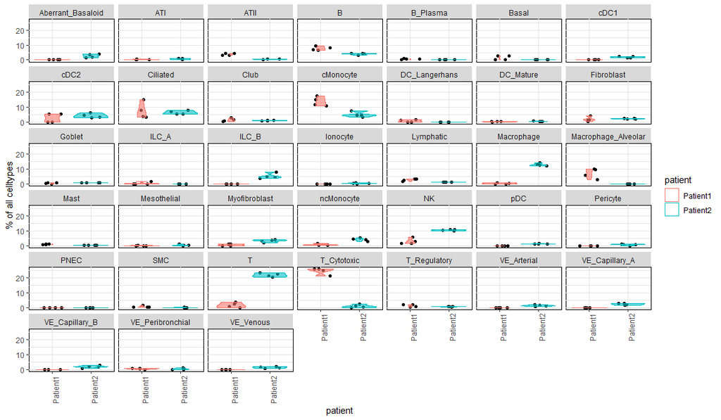

```r
ggplot(RBE.df.t.g, aes(fill=patient, y=value, x=patient)) +
geom_jitter(stat="identity", width = 0.25) +
  ylab("% of all celltypes") +
  geom_violin(aes(colour=patient), alpha=0.6)+
  facet_wrap(~celltype) +
  theme(axis.text.x = element_text(angle = 90, hjust = 1)) +
  guides(fill=FALSE) +
  theme(panel.background = element_rect(fill = "white", size = 0.5, color = "black")) +
  theme(panel.grid.major = element_line(colour = "gray90")) +
  theme(panel.grid.minor = element_line(colour = "gray90")) +
  theme(legend.key = element_rect(fill="white"))
```

Cells used in analysis:

|  | Subject_Identity | CellBarcode_Identity | nUMI | nGene | CellType_Category | Manuscript_Identity | Subclass_Cell_Identity | Disease_Identity | Library_Identity | new_label |
| --- | --- | --- | --- | --- | --- | --- | --- | --- | --- | --- |
| 1872 | 002C | 002C_ACTTACTCAAGAAAGG | 5200 | 2070 | Lymphoid | T | T | Control | 002C | 465C-002C-137C |
| 1876 | 002C | 002C_GCATGCGAGACTTTCG | 5344 | 2250 | Lymphoid | T_Cytotoxic | T_Cytotoxic_A | Control | 002C | 465C-002C-137C |
| 1877 | 002C | 002C_GCACATAGTAGCTAAA | 17523 | 4025 | Myeloid | Macrophage | Macrophage | Control | 002C | 465C-002C-137C |
| 1879 | 002C | 002C_GCAAACTAGGTTACCT | 19524 | 5942 | Multiplet | Multiplet | Multiplet_Secretory_Ciliated | Control | 002C | 465C-002C-137C |
| 1880 | 002C | 002C_GCAATCATCTCAACTT | 19523 | 4815 | Myeloid | Macrophage | Macrophage | Control | 002C | 465C-002C-137C |
| 1890 | 002C | 002C_AGGTCATAGACTAAGT | 11810 | 3639 | Myeloid | Macrophage | Macrophage | Control | 002C | 465C-002C-137C |
| 1903 | 002C | 002C_GAGTCCGTCACATACG | 5687 | 2476 | Lymphoid | T | T | Control | 002C | 465C-002C-137C |
| 1910 | 002C | 002C_ACGGAGAAGTAAGTAC | 9703 | 4090 | Epithelial | Ciliated | Ciliated | Control | 002C | 465C-002C-137C |
| 1917 | 002C | 002C_AGCGTCGGTATTAGCC | 12431 | 2804 | Myeloid | cDC1 | Dendritic_B | Control | 002C | 465C-002C-137C |
| 1925 | 002C | 002C_AGGGAGTAGGACAGAA | 1355 | 932 | Lymphoid | T | T | Control | 002C | 465C-002C-137C |

[output cut: 990 more lines]